# Automating Reviews in Medicine

Quang Duong

2017-07-13

The medical literature is enormous. Pubmed, a database of medical publications maintained by the U.S. National Library of Medicine, has indexed over 23 million medical publications. Further, the rate of medical publication has increased over time, and now there are nearly 1 million new publications in the field each year, or more than one per minute.

The large size and fast-changing nature of the medical literature has increased the need for reviews, which search databases like Pubmed for papers on a particular topic and then report results from the papers found. While such reviews are often performed manually, with multiple people reviewing each search result, this is tedious and time consuming. In this problem, we will see how text analytics can be used to automate the process of information retrieval.

The dataset consists of the titles (variable title) and abstracts (variable abstract) of papers retrieved in a Pubmed search. Each search result is labeled with whether the paper is a clinical trial testing a drug therapy for cancer (variable trial). These labels were obtained by two people reviewing each search result and accessing the actual paper if necessary, as part of a literature review of clinical trials testing drug therapies for advanced and metastatic breast cancer.

## Loading the Data

Load clinical_trial.csv into a data frame called trials (remembering to add the argument stringsAsFactors=FALSE), and investigate the data frame with summary() and str().

```r
trials <- read.csv("clinical_trial.csv", stringsAsFactors = FALSE)
str(trials)
summary(trials)
```

```
'data.frame':   1860 obs. of  3 variables:
 $ title   : chr  "Treatment of Hodgkin's disease and other cancers with 1,3-bis(2-chloroethyl)-1-nitrosourea (BCNU; NSC-409962)." "Cell mediated immune status in malignancy--pretherapy and post-therapy assessment." "Neoadjuvant vinorelbine-capecitabine versus docetaxel-doxorubicin-cyclophosphamide …
 $ abstract: chr  "" "Twenty-eight cases of malignancies of different kinds were studied to assess T-cell activity and population bef"| __truncated__ "BACKGROUND: Among breast cancer patients, nonresponse to initial neoadjuvant chemotherapy is associated with un"| __truncated__ "BACKGROUND: Taxanes …
 $ trial   : int  1 0 1 1 1 0 1 0 0 0 ...
    title             abstract             trial
 Length:1860        Length:1860        Min.   :0.0000
 Class :character   Class :character   1st Qu.:0.0000
 Mode  :character   Mode  :character   Median :0.0000
                                       Mean   :0.4392
                                       3rd Qu.:1.0000
                                       Max.   :1.0000
```

How many characters are there in the longest abstract? (Longest here is defined as the abstract with the largest number of characters.)

```r
max(nchar(trials$abstract))
```

```
[1] 3708
```

How many search results provided no abstract?

```r
sum(nchar(trials$abstract)==0)
```

```
[1] 112
```

Find the observation with the minimum number of characters in the title (the variable “title”) out of all of the observations in this dataset. What is the text of the title of this article? Include capitalization and punctuation in your response, but don’t include the quotes.

```r
trials$title[which.min(nchar(trials$title))]
```

```
[1] "A decade of letrozole: FACE."
```

## Preparing the Corpus

Because we have both title and abstract information for trials, we need to build two corpera instead of one. Name them corpusTitle and corpusAbstract.

Following the commands from lecture, perform the following tasks (you might need to load the “tm” package first if it isn’t already loaded). Make sure to perform them in this order.

1. Convert the title variable to corpusTitle and the abstract variable to corpusAbstract.
2. Convert corpusTitle and corpusAbstract to lowercase.
3. Remove the punctuation in corpusTitle and corpusAbstract.
4. Remove the English language stop words from corpusTitle and corpusAbstract.
5. Stem the words in corpusTitle and corpusAbstract (each stemming might take a few minutes).
6. Build a document term matrix called dtmTitle from corpusTitle and dtmAbstract from corpusAbstract.
7. Limit dtmTitle and dtmAbstract to terms with sparseness of at most 95% (aka terms that appear in at least 5% of documents).
8. Convert dtmTitle and dtmAbstract to data frames (keep the names dtmTitle and dtmAbstract).

```r
library(tm)
library(SnowballC)
corpusTitle <- VCorpus(VectorSource(trials$title))
corpusAbstract <- VCorpus(VectorSource(trials$abstract))
corpusTitle <- tm_map(corpusTitle, content_transformer(tolower))
corpusAbstract <- tm_map(corpusAbstract, content_transformer(tolower))
corpusTitle <- tm_map(corpusTitle, content_transformer(removePunctuation))
corpusAbstract <- tm_map(corpusAbstract, content_transformer(removePunctuation))
corpusTitle <- tm_map(corpusTitle, removeWords, stopwords("english"))
corpusAbstract <- tm_map(corpusAbstract, removeWords, stopwords("english"))
corpusTitle <- tm_map(corpusTitle, stemDocument)
corpusAbstract <- tm_map(corpusAbstract, stemDocument)
dtmTitle <- DocumentTermMatrix(corpusTitle)
dtmAbstract <- DocumentTermMatrix(corpusAbstract)
dtmTitle <- removeSparseTerms(dtmTitle, sparse = 0.95)
dtmAbstract <- removeSparseTerms(dtmAbstract, sparse = 0.95)
dtmTitle <- as.data.frame(as.matrix(dtmTitle))
dtmAbstract <- as.data.frame(as.matrix(dtmAbstract))
```

How many terms remain in dtmTitle after removing sparse terms (aka how many columns does it have)?

```r
str(dtmTitle)
```

```
'data.frame':   1860 obs. of  31 variables:
 $ adjuv          : num  0 0 0 0 0 0 0 0 1 0 ...
 $ advanc         : num  0 0 0 0 0 0 1 0 0 0 ...
 $ breast         : num  0 0 1 1 1 1 0 1 1 1 ...
 $ cancer         : num  1 0 1 1 1 1 0 1 1 2 ...
 $ chemotherapi   : num  0 0 0 0 1 1 0 0 0 0 ...
 $ clinic         : num  0 0 0 0 0 0 0 0 0 0 ...
 $ combin         : num  0 0 0 0 1 0 1 0 0 0 ...
 $ compar         : num  0 0 0 0 0 0 0 0 0 0 ...
 $ cyclophosphamid: num  0 0 0 1 0 0 0 0 0 0 ...
 $ docetaxel      : num  0 0 0 0 0 0 0 0 0 0 ...
 $ doxorubicin    : num  0 0 0 0 0 0 0 0 0 0 ...
 $ earli          : num  0 0 1 1 0 0 0 1 0 0 ...
 $ effect         : num  0 0 0 0 1 0 0 1 0 1 ...
 $ group          : num  0 0 0 0 0 0 0 0 1 1 ...
```

[output cut: 17 more lines]

How many terms remain in dtmAbstract?

```r
str(dtmAbstract)
```

```
'data.frame':   1860 obs. of  335 variables:
 $ 0001           : num  0 0 0 0 0 7 0 0 0 0 ...
 $ 001            : num  0 0 0 1 0 0 0 1 0 0 ...
 $ 005            : num  0 0 0 0 0 0 0 0 0 0 ...
 $ 100            : num  0 1 0 0 0 0 0 0 0 0 ...
 $ 500            : num  0 0 1 0 2 0 0 0 0 0 ...
 $ 5fluorouracil  : num  0 0 0 0 0 1 0 0 0 0 ...
 $ accord         : num  0 0 0 0 0 0 0 0 0 0 ...
 $ achiev         : num  0 0 0 0 0 0 1 0 1 0 ...
 $ activ          : num  0 2 0 1 0 0 1 0 0 0 ...
 $ addit          : num  0 0 2 0 0 0 0 0 0 0 ...
 $ adjuv          : num  0 0 0 2 0 1 0 2 4 0 ...
 $ administ       : num  0 0 0 0 0 0 1 0 0 0 ...
 $ administr      : num  0 0 0 0 0 0 0 0 0 0 ...
 $ advanc         : num  0 0 0 0 0 0 1 0 0 0 ...
```

[output cut: 86 more lines]

What is the most likely reason why dtmAbstract has so many more terms than dtmTitle?

Abstracts tend to have many more words than titles correct

What is the most frequent word stem across all the abstracts?

```r
which.max(colSums(dtmAbstract))
```

```
patient
    212
```

## Building a model

We want to combine dtmTitle and dtmAbstract into a single data frame to make predictions. However, some of the variables in these data frames have the same names. To fix this issue, run the following commands:

```r
colnames(dtmTitle) <- paste0("T", colnames(dtmTitle))
colnames(dtmAbstract) <- paste0("A", colnames(dtmAbstract))
```

Using cbind(), combine dtmTitle and dtmAbstract into a single data frame called dtm:

```r
dtm <- cbind(dtmTitle, dtmAbstract)
```

As we did in class, add the dependent variable “trial” to dtm, copying it from the original data frame called trials. How many columns are in this combined data frame?

```r
dtm$trial <- trials$trial
str(dtm)
```

```
'data.frame':   1860 obs. of  367 variables:
 $ Tadjuv          : num  0 0 0 0 0 0 0 0 1 0 ...
 $ Tadvanc         : num  0 0 0 0 0 0 1 0 0 0 ...
 $ Tbreast         : num  0 0 1 1 1 1 0 1 1 1 ...
 $ Tcancer         : num  1 0 1 1 1 1 0 1 1 2 ...
 $ Tchemotherapi   : num  0 0 0 0 1 1 0 0 0 0 ...
 $ Tclinic         : num  0 0 0 0 0 0 0 0 0 0 ...
 $ Tcombin         : num  0 0 0 0 1 0 1 0 0 0 ...
 $ Tcompar         : num  0 0 0 0 0 0 0 0 0 0 ...
 $ Tcyclophosphamid: num  0 0 0 1 0 0 0 0 0 0 ...
 $ Tdocetaxel      : num  0 0 0 0 0 0 0 0 0 0 ...
 $ Tdoxorubicin    : num  0 0 0 0 0 0 0 0 0 0 ...
 $ Tearli          : num  0 0 1 1 0 0 0 1 0 0 ...
 $ Teffect         : num  0 0 0 0 1 0 0 1 0 1 ...
 $ Tgroup          : num  0 0 0 0 0 0 0 0 1 1 ...
```

[output cut: 86 more lines]

Now that we have prepared our data frame, it’s time to split it into a training and testing set and to build regression models. Set the random seed to 144 and use the sample.split function from the caTools package to split dtm into data frames named “train” and “test”, putting 70% of the data in the training set.

What is the accuracy of the baseline model on the training set? (Remember that the baseline model predicts the most frequent outcome in the training set for all observations.)

```r
library(caTools)
spl <- sample.split(dtm$trial, SplitRatio = 0.7)
set.seed(144)
trainSet <- subset(dtm, spl == TRUE)
testSet <- subset(dtm, spl == FALSE)
table(trainSet$trial)
(730)/(730+572)
```

```
  0   1
730 572
[1] 0.5606759
```

Build a CART model called trialCART, using all the independent variables in the training set to train the model, and then plot the CART model. Just use the default parameters to build the model (don’t add a minbucket or cp value). Remember to add the method=“class” argument, since this is a classification problem.

What is the name of the first variable the model split on?

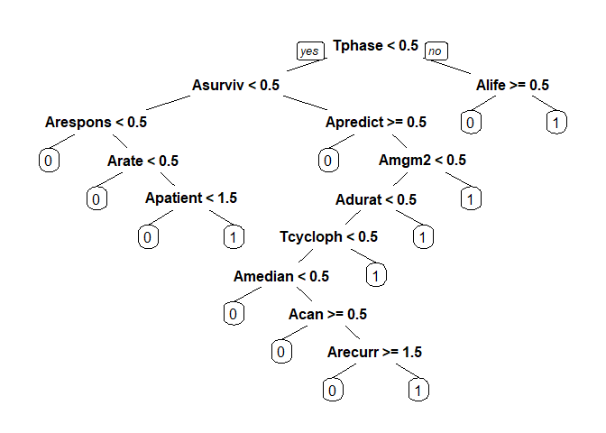

```r
library(rpart)
library(rpart.plot)
trialCART <- rpart(trial ~ ., data = trainSet, method = "class")
prp(trialCART)
```

Obtain the training set predictions for the model (do not yet predict on the test set). Extract the predicted probability of a result being a trial (recall that this involves not setting a type argument, and keeping only the second column of the predict output). What is the maximum predicted probability for any result?

```r
predCART <- predict(trialCART)
max(predCART[,2])
```

```
[1] 0.9047619
```

Without running the analysis, how do you expect the maximum predicted probability to differ in the testing set?

Because the CART tree assigns the same predicted probability to each leaf node and there are a small number of leaf nodes compared to data points, we expect exactly the same maximum predicted probability.

For these questions, use a threshold probability of 0.5 to predict that an observation is a clinical trial.

What is the training set accuracy of the CART model?

```r
table(trainSet$trial, predCART[,2]>=0.5)
(631+441)/(631+441+99+131)
```

[output not shown]

What is the training set sensitivity of the CART model?

```r
441/(441+131)
```

```
[1] 0.770979
```

What is the training set specificity of the CART model?

```r
631/(631+99)
```

```
[1] 0.8643836
```

## Evaluating the model on the testing set

Evaluate the CART model on the testing set using the predict function and creating a vector of predicted probabilities predTest.

What is the testing set accuracy, assuming a probability threshold of 0.5 for predicting that a result is a clinical trial?

```r
predTest <- predict(trialCART, newdata = testSet, type = "class")
table(testSet$trial, predTest)
(261+162)/(261+162+52+83)
```

[output not shown]

Using the ROCR package, what is the testing set AUC of the prediction model?

```r
library(ROCR)
predTest <- predict(trialCART, newdata = testSet)
predTestROCR <- prediction(predTest[,2], testSet$trial)
as.numeric(performance(predTestROCR, "auc")@y.values)
```

```
[1] 0.8230945
```

## Decision-Maker Tradeoffs

What is the cost associated with the model in Step 1 making a false negative prediction?

A paper that should have been included in Set A will be missed, affecting the quality of the results of Step 3.

By definition, a false negative is a paper that should have been included in Set A but was missed by the model. This means a study that should have been included in Step 3 was missed, affecting the results.

What is the cost associated with the model in Step 1 making a false positive prediction?

A paper will be mistakenly added to Set A, yielding additional work in Step 2 of the process but not affecting the quality of the results of Step 3.

By definition, a false positive is a paper that should not have been included in Set A but that was actually included. However, because the manual review in Step 2 is assumed to be 100% effective, this extra paper will not make it into the more limited set of papers, and therefore this mistake will not affect the analysis in Step 3.

Given the costs associated with false positives and false negatives, which of the following is most accurate?

A false negative is more costly than a false positive; the decision maker should use a probability threshold less than 0.5 for the machine learning model. correct

A false negative might negatively affect the results of the literature review and analysis, while a false positive is a nuisance (one additional paper that needs to be manually checked). As a result, the cost of a false negative is much higher than the cost of a false positive, so much so that many studies actually use no machine learning (aka no Step 1) and have two people manually review each search result in Step 2. As always, we prefer a lower threshold in cases where false negatives are more costly than false positives, since we will make fewer negative predictions.